# Assignment1_stats359

Koki Itagaki

2023-01-30

#Question 2: Suppose the following data comes from a study on plant growth (mm) #where 2 plants are in each pot, 3 pots are within each plot and 2 plots are #given one of two fertilizer treatments.

```
##    growth plot Pot treatment
## 1    14.6    1   1         1
## 2    15.2    1   1         1
## 3    18.5    2   1         1
## 4    16.7    2   1         1
## 5    13.2    1   2         1
## 6    12.9    1   2         1
## 7    22.2    2   2         1
## 8    18.8    2   2         1
## 9    16.4    1   3         1
## 10   12.2    1   3         1
## 11   24.7    2   3         1
## 12   20.3    2   3         1
## 13    7.1    1   1         2
## 14    7.7    1   1         2
## 15    9.7    2   1         2
## 16    8.8    2   1         2
## 17    6.8    1   2         2
## 18    6.0    1   2         2
## 19    6.8    2   2         2
## 20    9.0    2   2         2
## 21   10.0    1   3         2
## 22    8.3    1   3         2
## 23   10.4    2   3         2
## 24   11.3    2   3         2
```

```
##  [1]  6.0  6.8  6.8  7.1  7.7  8.3  8.8  9.0  9.7 10.0 10.4 11.3 12.2 12.9 13.2
## [16] 14.6 15.2 16.4 16.7 18.5 18.8 20.3 22.2 24.7
```

```
## [1] 12.81667
```

```
## [1] 5.296813
```

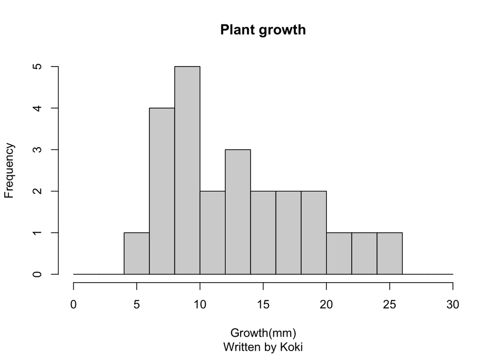

#Question 3: Write a function that uses the short cut formula to calculate #the sample variance of a data vector. #Use the vector y=(11,11,10,8,11,3,15,11,7,6) as your test vector.

```
## [1] 11.34444
```

#Question4: On the course webpage you will find a dataset with filename ‘tv.txt’ #The data arise from a study examining the time teenagers spend watching tv. #A random sample of n = 100 eighth grade American high school students was #obtained, and the number of minutes spent watching TV during the first week #of October was recorded. A similar sample of m = 90 Canadian students was also #obtained. In this study it is of interest to compare the TV watching habits of #the teenagers from the two different countries, specifically to determine #if Canadian students watch less TV than their American counterparts.

```
##         Canada       US
## 1    76.972030 65.71819
## 2    81.930050 66.84723
## 3    10.287570 72.77606
## 4    46.531230 73.58473
## 5    84.947600 69.39871
## 6    91.493270 67.56986
## 7    45.420800 71.57007
## 8    48.490550 65.10214
## 9    74.460080 63.34076
## 10   89.445170 71.82348
## 11   76.351960 62.37042
## 12   78.265030 71.44686
## 13   43.435870 62.32819
## 14   54.291900 71.52563
```

[output cut: 86 more lines]

```
##      Canada              US
##  Min.   :  6.781   Min.   :53.19
##  1st Qu.: 48.667   1st Qu.:65.58
##  Median : 67.995   Median :69.47
##  Mean   : 64.313   Mean   :69.33
##  3rd Qu.: 82.340   3rd Qu.:73.21
##  Max.   :109.433   Max.   :79.74
##  NA's   :10
```

```
## [1] 64.31260 69.33279
```

```
##    Min. 1st Qu.  Median    Mean 3rd Qu.    Max.
##   6.781  48.667  67.995  64.313  82.340 109.433
```

```
##    Min. 1st Qu.  Median    Mean 3rd Qu.    Max.
##   53.19   65.58   69.47   69.33   73.21   79.74
```

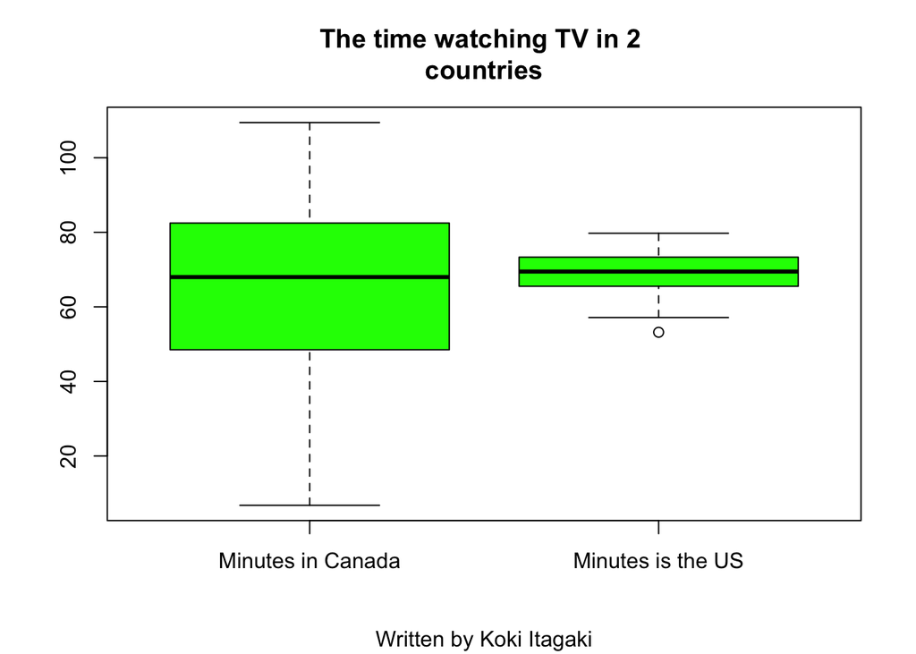

```
## [1] 0.04417275
```

```
## [1] 0.9779136
```

```
## [1] 0.02208637
```

#(d) Which of the three alternative hypotheses is relevant for the particular #question being asked in this study? Comment on the results.

#My answer: We would like to know if tenagers in Canada watch TV less time than teenagers in the U.S.Let u1 = the average time teenagers in Canada watch TV and let u2 = the time teenagers in the U.S watch the TV. So the alternative hypotheses is Ha: u1 - u2 < 0 (or u1 < u2)